# DDP Week Four Project

3/16/2021

## Introduction

This slide show presents the Shiny application I created for the final project of the Developing Data Products course.

The Shiny application can be found here:

https://wgreena1.shinyapps.io/DDP_Week_4_Project/

The source code for the Shiny application can be found here:

https://github.com/wgreena1/DDP_Week_4_Project

## Dataset

This Shiny application was created for use with the ChickWeight dataset from the R datasets package. The dimensions of this dataset are:

```
## [1] 578   4
```

This dataset includes the following variables:

```
## [1] "weight" "Time"   "Chick"  "Diet"
```

## Application Purpose

The purpose of the Shiny app is to provide a tool that allows the user to predict the weight of a chick based on two input variables:

- age (in days)
- diet

The weight prediction is based on a linear model created using the ChickWeight dataset.

## Loading the Shiny Application

When the Shiny application is loaded, both a user input interface and a scatterplot of the ChickWeight data (as seen below) are displayed.

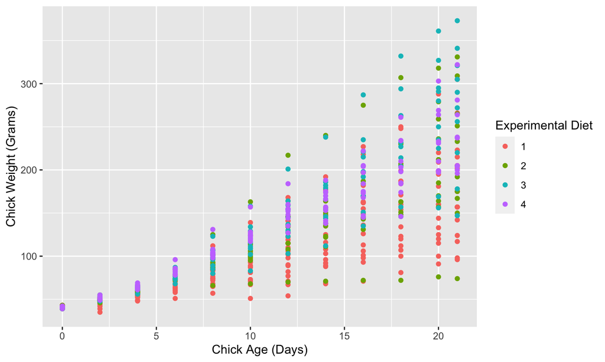

## Using the Shiny Application

Inputs are selected by the user with either a slider (chick age) or drop-down menu tool (chick diet).

There is also an option for the user to select to add a regression line to the scatterplot that corresponds to the linear model (weight ~ age) for the selected chick diet.

After the user makes their selections, the “submit” button must be pressed.

## Shiny Application Output

After the user has hit the submit button, the predicted chick weight is displayed in the main panel.

If the user has selected to display the regression line, this line (with error bars) will be added to the plot.